# Lab 4: Regression and Classification Evaluation Metrics

## Part 1: KNN Classification using Breast Cancer Dataset and Comparison with Regression Metrics

**Author:** AIML Student  
**OS Version:** Windows  
**Workspace:** `Arpan7125/AIML`

### Aim

- **Implement KNN:** Build a K-Nearest Neighbors classifier for breast cancer detection.
- **Optimize:** Use $\sqrt{n}$ heuristic, train-test splits, and cross-validation to find the best $K$.
- **Evaluate:** Test model performance using Accuracy, Precision, Recall, F1 Score, and ROC-AUC.
- **Compare:** See how classification metrics stack up against regression metrics from Lab 3.

### Environment Setup and Imports

We first import the required libraries for data manipulation, scaling, classification, visualization, and metrics evaluation.

```python
import os
import numpy as np
import pandas as pd
import matplotlib.pyplot as plt
import seaborn as sns
from sklearn.datasets import load_breast_cancer
from sklearn.model_selection import train_test_split, cross_val_score, KFold
from sklearn.preprocessing import StandardScaler
from sklearn.neighbors import KNeighborsClassifier
from sklearn.decomposition import PCA
from sklearn.metrics import (
    accuracy_score, precision_score, recall_score, f1_score,
    confusion_matrix, roc_curve, auc, classification_report
)

# Set plotting style
sns.set_theme(style="whitegrid")
plt.rcParams.update({
    'font.size': 11,
    'axes.labelsize': 12,
    'axes.titlesize': 13,
    'xtick.labelsize': 10,
    'ytick.labelsize': 10,
    'figure.titlesize': 14
})

# Make directory for images if it doesn't exist
os.makedirs("images", exist_ok=True)
print("Libraries imported and plotting environment initialized.")
```

```
Libraries imported and plotting environment initialized.
```

## Task 1: Data Preparation

We load the Breast Cancer dataset, check its structure, handle any missing values, and scale the features.

### Why do we scale features in KNN?

- **Distance matters:** KNN relies on calculating distance between points, like Euclidean distance: $$d(\mathbf{p}, \mathbf{q}) = \sqrt{\sum_{i=1}^d (p_i - q_i)^2}$$
- **Even playing field:** If one feature is measured in thousands (e.g., area) and another in decimals (e.g., smoothness), the large numbers will overpower the small ones.
- **The fix:** We use `StandardScaler` ($\mu=0, \sigma^2=1$) to ensure every feature has equal weight.

```python
# 1.1 Load the Breast Cancer dataset
cancer_data = load_breast_cancer()
X = pd.DataFrame(cancer_data.data, columns=cancer_data.feature_names)
y = pd.Series(cancer_data.target, name="target")

# 1.2 Explore the structure
print("--- Data Structure & Shape ---")
print(f"Dataset Shape: {X.shape[0]} samples, {X.shape[1]} features")
print(f"Target distribution (Counts):\n{y.value_counts()}")
print(f"Target distribution (Percentages):\n{y.value_counts(normalize=True) * 100}\n")

# 1.3 Check missing values and duplicates
missing = X.isnull().sum().sum()
duplicates = X.duplicated().sum()
print(f"Total Missing Values: {missing}")
print(f"Total Duplicate Rows: {duplicates}\n")

# 1.4 Apply Feature Scaling
scaler = StandardScaler()
X_scaled = scaler.fit_transform(X)
X_scaled_df = pd.DataFrame(X_scaled, columns=cancer_data.feature_names)
print("First 3 rows of scaled features:")
X_scaled_df.head(3)
```

```
--- Data Structure & Shape ---
Dataset Shape: 569 samples, 30 features
Target distribution (Counts):
target
1    357
0    212
Name: count, dtype: int64
Target distribution (Percentages):
target
1    62.741652
0    37.258348
Name: proportion, dtype: float64

Total Missing Values: 0
Total Duplicate Rows: 0

First 3 rows of scaled features:
```

|  | mean radius | mean texture | mean perimeter | mean area | mean smoothness | mean compactness | mean concavity | mean concave points | mean symmetry | mean fractal dimension | ... | worst radius | worst texture | worst perimeter | worst area | worst smoothness | worst compactness | worst concavity | worst concave points | worst symmetry | worst fractal dimension |
| --- | --- | --- | --- | --- | --- | --- | --- | --- | --- | --- | --- | --- | --- | --- | --- | --- | --- | --- | --- | --- | --- |
| 0 | 1.097064 | -2.073335 | 1.269934 | 0.984375 | 1.568466 | 3.283515 | 2.652874 | 2.532475 | 2.217515 | 2.255747 | ... | 1.886690 | -1.359293 | 2.303601 | 2.001237 | 1.307686 | 2.616665 | 2.109526 | 2.296076 | 2.750622 | 1.937015 |
| 1 | 1.829821 | -0.353632 | 1.685955 | 1.908708 | -0.826962 | -0.487072 | -0.023846 | 0.548144 | 0.001392 | -0.868652 | ... | 1.805927 | -0.369203 | 1.535126 | 1.890489 | -0.375612 | -0.430444 | -0.146749 | 1.087084 | -0.243890 | 0.281190 |
| 2 | 1.579888 | 0.456187 | 1.566503 | 1.558884 | 0.942210 | 1.052926 | 1.363478 | 2.037231 | 0.939685 | -0.398008 | ... | 1.511870 | -0.023974 | 1.347475 | 1.456285 | 0.527407 | 1.082932 | 0.854974 | 1.955000 | 1.152255 | 0.201391 |

3 rows × 30 columns

## Task 2: Train-Test Split Analysis

We experiment with three different splits: **80:20**, **70:30**, and **90:10** to see how the model behaves.

### Which split is best?

- **90:10 Split:** Too few test samples. Even a single mistake drastically swings the accuracy (unstable).
- **70:30 Split:** Good for testing, but leaves less data for the model to learn from (can reduce performance).
- **80:20 Split:** The sweet spot! It perfectly balances a solid training size with a reliable test size.

```python
splits = [(0.2, "80:20"), (0.3, "70:30"), (0.1, "90:10")]
split_results = []

for test_size, name in splits:
    # Use stratify=y to maintain class distribution in splits
    X_train, X_test, y_train, y_test = train_test_split(
        X_scaled, y, test_size=test_size, random_state=42, stratify=y
    )

    # Heuristic K rule
    n_train = len(X_train)
    heuristic_k = int(np.round(np.sqrt(n_train)))
    if heuristic_k % 2 == 0:
        heuristic_k += 1  # ensure odd K to break ties

    # Fit model
    knn = KNeighborsClassifier(n_neighbors=heuristic_k)
    knn.fit(X_train, y_train)

    # Predict
    y_train_pred = knn.predict(X_train)
    y_test_pred = knn.predict(X_test)

    split_results.append({
        "Split Ratio": name,
        "Train Size": len(X_train),
        "Test Size": len(X_test),
        "Heuristic K": heuristic_k,
        "Train Acc": accuracy_score(y_train, y_train_pred),
        "Test Acc": accuracy_score(y_test, y_test_pred),
        "Precision": precision_score(y_test, y_test_pred),
        "Recall": recall_score(y_test, y_test_pred),
        "F1 Score": f1_score(y_test, y_test_pred)
    })

split_analysis_df = pd.DataFrame(split_results)
split_analysis_df
```

|  | Split Ratio | Train Size | Test Size | Heuristic K | Train Acc | Test Acc | Precision | Recall | F1 Score |
| --- | --- | --- | --- | --- | --- | --- | --- | --- | --- |
| 0 | 80:20 | 455 | 114 | 21 | 0.964835 | 0.956140 | 0.946667 | 0.986111 | 0.965986 |
| 1 | 70:30 | 398 | 171 | 21 | 0.969849 | 0.947368 | 0.922414 | 1.000000 | 0.959641 |
| 2 | 90:10 | 512 | 57 | 23 | 0.962891 | 0.982456 | 0.972973 | 1.000000 | 0.986301 |

## Task 3: KNN Model with Heuristic K Selection

### 3.1 The Square Root Rule

- A great starting point for finding $K$ is $K = \sqrt{n}$ (where $n$ is your training size).
- For 455 training samples, $\sqrt{455} \approx 21.33$.
- We round this to **21** (always use an odd number to avoid ties during voting!).

### 3.2 Tuning the Model

We train our model at $K=21$ and then test nearby values (from 16 to 26) to see if we can find an even better fit.

```
Heuristic K: 21
Best K in heuristic range 16 to 26: K = 18 (Test Acc: 0.9825)
```

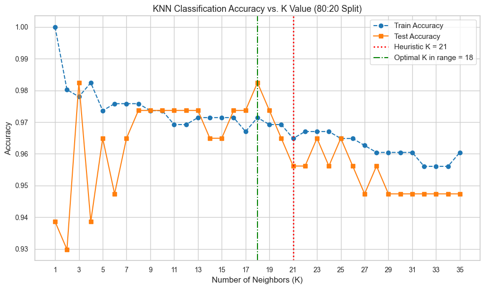

```python
# Base split is 80:20
X_train, X_test, y_train, y_test = train_test_split(
    X_scaled, y, test_size=0.2, random_state=42, stratify=y
)
n_train = len(X_train)
h_k = int(np.round(np.sqrt(n_train)))
if h_k % 2 == 0:
    h_k += 1

# Define range to plot
k_range = list(range(1, 36))
train_accs = []
test_accs = []

for k in k_range:
    model = KNeighborsClassifier(n_neighbors=k)
    model.fit(X_train, y_train)
    train_accs.append(accuracy_score(y_train, model.predict(X_train)))
    test_accs.append(accuracy_score(y_test, model.predict(X_test)))

# Find best K within Heuristic K +- 5 range
k_subset = list(range(h_k - 5, h_k + 6))
subset_test_accs = [test_accs[k-1] for k in k_subset]
best_h_k = k_subset[np.argmax(subset_test_accs)]

print(f"Heuristic K: {h_k}")
print(f"Best K in heuristic range {h_k-5} to {h_k+5}: K = {best_h_k} (Test Acc: {max(subset_test_accs):.4f})")

# Plot Accuracy vs K
plt.figure(figsize=(10, 6))
plt.plot(k_range, train_accs, label="Train Accuracy", marker='o', linestyle="--", color="#1f77b4")
plt.plot(k_range, test_accs, label="Test Accuracy", marker='s', color="#ff7f0e")
plt.axvline(x=h_k, color="red", linestyle=":", lw=2, label=f"Heuristic K = {h_k}")
plt.axvline(x=best_h_k, color="green", linestyle="-.", lw=1.5, label=f"Optimal K in range = {best_h_k}")
plt.title("KNN Classification Accuracy vs. K Value (80:20 Split)")
plt.xlabel("Number of Neighbors (K)")
plt.ylabel("Accuracy")
plt.xticks(range(1, 36, 2))
plt.legend()
plt.tight_layout()
plt.savefig("images/accuracy_vs_k.png", dpi=150)
plt.show()
```

### 3.3 Distance Metrics & Decision Boundaries

#### Euclidean vs. Manhattan Distance

- **Euclidean:** Straight-line distance. Great for standard, continuous data but struggles if you have extreme outliers or too many dimensions. $$d(\mathbf{p}, \mathbf{q}) = \sqrt{\sum_{i=1}^d (p_i - q_i)^2}$$
- **Manhattan:** Grid-like (taxicab) distance. Perfect for categorical data or grid-based paths, and it handles outliers much better. $$d(\mathbf{p}, \mathbf{q}) = \sum_{i=1}^d |p_i - q_i|$$

#### Decision Boundaries (Visualizing K)

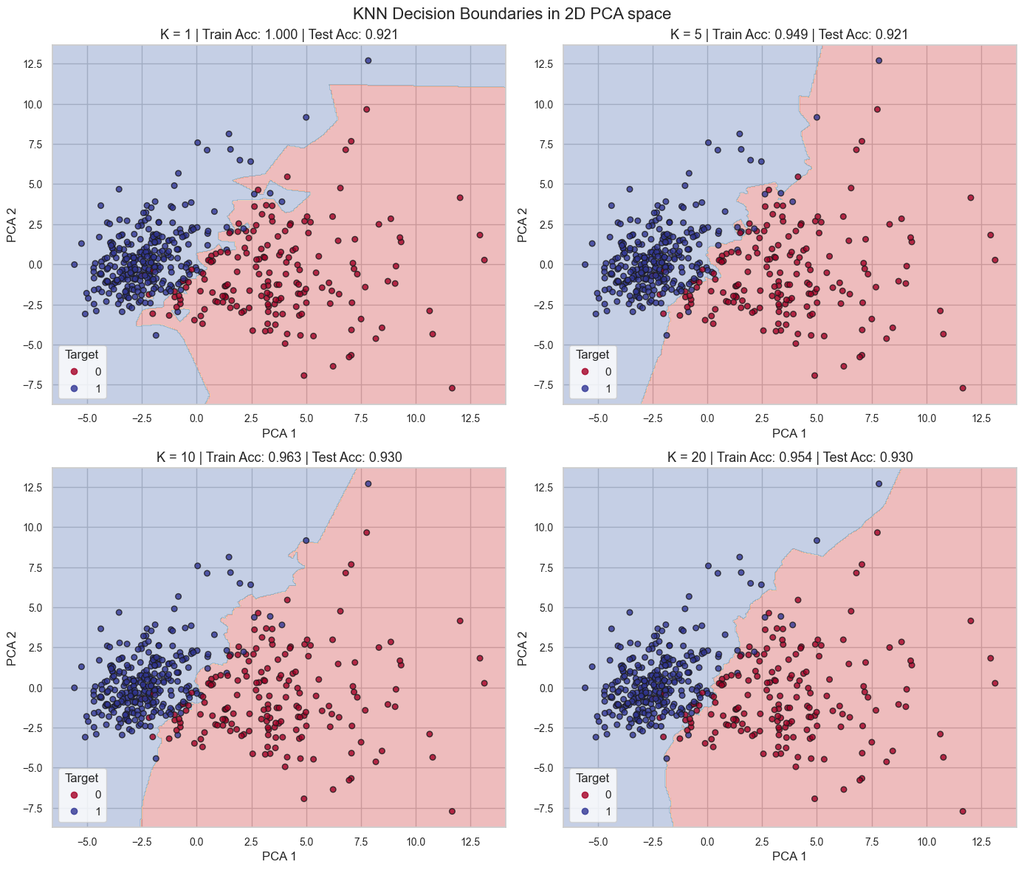

```python
# PCA projection to 2D
pca = PCA(n_components=2)
X_train_pca = pca.fit_transform(X_train)
X_test_pca = pca.transform(X_test)

# Plot decision boundaries
k_vals = [1, 5, 10, 20]
fig, axes = plt.subplots(2, 2, figsize=(14, 12))
axes = axes.ravel()

# Create meshgrid
x_min, x_max = X_train_pca[:, 0].min() - 1, X_train_pca[:, 0].max() + 1
y_min, y_max = X_train_pca[:, 1].min() - 1, X_train_pca[:, 1].max() + 1
xx, yy = np.meshgrid(np.arange(x_min, x_max, 0.05),
                     np.arange(y_min, y_max, 0.05))

for i, k in enumerate(k_vals):
    knn_pca = KNeighborsClassifier(n_neighbors=k)
    knn_pca.fit(X_train_pca, y_train)

    Z = knn_pca.predict(np.c_[xx.ravel(), yy.ravel()]).reshape(xx.shape)

    # Plot contours
    axes[i].contourf(xx, yy, Z, alpha=0.3, cmap=plt.cm.RdYlBu)
    scatter = axes[i].scatter(X_train_pca[:, 0], X_train_pca[:, 1], c=y_train,
                              cmap=plt.cm.RdYlBu, edgecolor='k', s=30, alpha=0.8)

    # Labels and Titles
    train_acc = accuracy_score(y_train, knn_pca.predict(X_train_pca))
    test_acc = accuracy_score(y_test, knn_pca.predict(X_test_pca))
    axes[i].set_title(f"K = {k} | Train Acc: {train_acc:.3f} | Test Acc: {test_acc:.3f}")
    axes[i].set_xlabel("PCA 1")
    axes[i].set_ylabel("PCA 2")
    axes[i].legend(*scatter.legend_elements(), loc="lower left", title="Target")

plt.suptitle("KNN Decision Boundaries in 2D PCA space", y=0.98, fontsize=16)
plt.tight_layout()
plt.savefig("images/decision_boundaries.png", dpi=150)
plt.show()
```

## Task 4: Cross-Validation

A single train-test split can be "lucky" or "unlucky" depending on how the data was shuffled.

### Why Cross-Validation?

- We chop the data into 10 chunks (folds).
- We train on 9 chunks and test on the 1, rotating until every chunk has been a test set.
- This gives us a much more reliable and robust estimate of how the model will perform in the real world.

```
Optimal K from 10-Fold CV: K = 11 (Mean Accuracy = 0.9701 ± 0.0196)
```

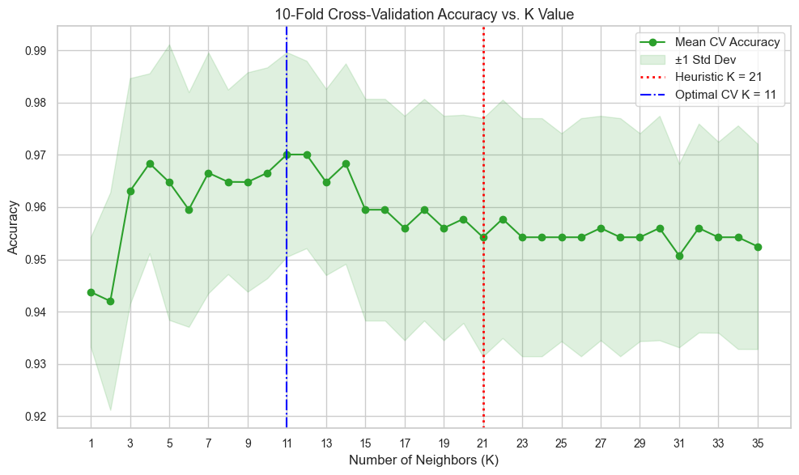

```python
# 10-Fold Cross-Validation Setup
kf = KFold(n_splits=10, shuffle=True, random_state=42)
cv_means = []
cv_stds = []

for k in k_range:
    knn_cv = KNeighborsClassifier(n_neighbors=k)
    scores = cross_val_score(knn_cv, X_scaled, y, cv=kf, scoring='accuracy')
    cv_means.append(scores.mean())
    cv_stds.append(scores.std())

cv_means = np.array(cv_means)
cv_stds = np.array(cv_stds)

# Find best K from CV
best_cv_idx = np.argmax(cv_means)
best_cv_k = k_range[best_cv_idx]
print(f"Optimal K from 10-Fold CV: K = {best_cv_k} (Mean Accuracy = {cv_means[best_cv_idx]:.4f} ± {cv_stds[best_cv_idx]:.4f})")

# Plot CV results
plt.figure(figsize=(10, 6))
plt.plot(k_range, cv_means, label="Mean CV Accuracy", color="#2ca02c", marker='o')
plt.fill_between(k_range, cv_means - cv_stds, cv_means + cv_stds, alpha=0.15, color="#2ca02c", label="±1 Std Dev")
plt.axvline(x=h_k, color="red", linestyle=":", lw=2, label=f"Heuristic K = {h_k}")
plt.axvline(x=best_cv_k, color="blue", linestyle="-.", lw=1.5, label=f"Optimal CV K = {best_cv_k}")
plt.title("10-Fold Cross-Validation Accuracy vs. K Value")
plt.xlabel("Number of Neighbors (K)")
plt.ylabel("Accuracy")
plt.xticks(range(1, 36, 2))
plt.legend()
plt.tight_layout()
plt.savefig("images/cv_accuracy_vs_k.png", dpi=150)
plt.show()
```

## Task 5: Classification Evaluation

Now we evaluate our winning model ($K = 11$) using the 80:20 split. We will look at **Accuracy**, **Precision**, **Recall**, **F1 Score**, the **Confusion Matrix**, and the **ROC-AUC** curve.

### Classification Formulas

- **Accuracy:** $\frac{\text{TP} + \text{TN}}{\text{TP} + \text{TN} + \text{FP} + \text{FN}}$
- **Precision:** $\frac{\text{TP}}{\text{TP} + \text{FP}}$
- **Recall:** $\frac{\text{TP}}{\text{TP} + \text{FN}}$
- **F1 Score:** $2 \times \frac{\text{Precision} \times \text{Recall}}{\text{Precision} + \text{Recall}}$

```
Final Model Metrics (K = 11):
Accuracy:  0.9737
Precision: 0.9600
Recall:    1.0000
F1 Score:  0.9796

Classification Report:
              precision    recall  f1-score   support

   malignant       1.00      0.93      0.96        42
      benign       0.96      1.00      0.98        72

    accuracy                           0.97       114
   macro avg       0.98      0.96      0.97       114
weighted avg       0.97      0.97      0.97       114
```

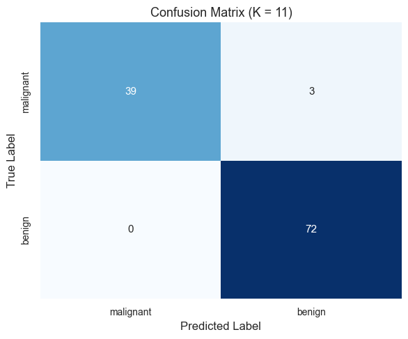

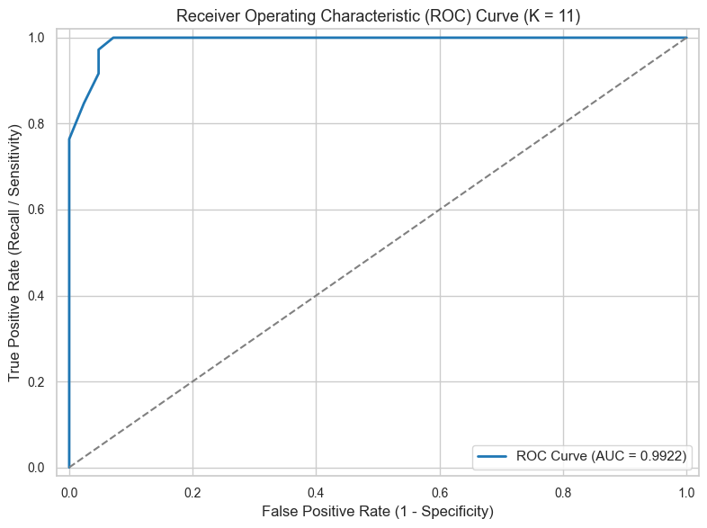

```python
# Train final model
final_knn = KNeighborsClassifier(n_neighbors=best_cv_k)
final_knn.fit(X_train, y_train)

y_pred = final_knn.predict(X_test)
y_proba = final_knn.predict_proba(X_test)[:, 1]

# Calculate metrics
acc = accuracy_score(y_test, y_pred)
prec = precision_score(y_test, y_pred)
rec = recall_score(y_test, y_pred)
f1 = f1_score(y_test, y_pred)

print(f"Final Model Metrics (K = {best_cv_k}):")
print(f"Accuracy:  {acc:.4f}")
print(f"Precision: {prec:.4f}")
print(f"Recall:    {rec:.4f}")
print(f"F1 Score:  {f1:.4f}\n")

print("Classification Report:")
print(classification_report(y_test, y_pred, target_names=cancer_data.target_names))

# Confusion Matrix Heatmap
cm = confusion_matrix(y_test, y_pred)
plt.figure(figsize=(6, 5))
sns.heatmap(cm, annot=True, fmt="d", cmap="Blues", cbar=False,
            xticklabels=cancer_data.target_names, yticklabels=cancer_data.target_names)
plt.title(f"Confusion Matrix (K = {best_cv_k})")
plt.xlabel("Predicted Label")
plt.ylabel("True Label")
plt.tight_layout()
plt.savefig("images/confusion_matrix.png", dpi=150)
plt.show()

# ROC Curve & AUC
fpr, tpr, thresholds = roc_curve(y_test, y_proba)
roc_auc = auc(fpr, tpr)

plt.figure(figsize=(8, 6))
plt.plot(fpr, tpr, color='#1f77b4', lw=2, label=f'ROC Curve (AUC = {roc_auc:.4f})')
plt.plot([0, 1], [0, 1], color='gray', linestyle='--')
plt.xlim([-0.02, 1.02])
plt.ylim([-0.02, 1.02])
plt.xlabel('False Positive Rate (1 - Specificity)')
plt.ylabel('True Positive Rate (Recall / Sensitivity)')
plt.title(f'Receiver Operating Characteristic (ROC) Curve (K = {best_cv_k})')
plt.legend(loc="lower right")
plt.tight_layout()
plt.savefig("images/roc_curve.png", dpi=150)
plt.show()
```

## Task 6: Comparative Study with Regression (Lab 3 Integration)

In Lab 3, we used metrics like **MAE**, **MSE**, **RMSE**, and **$R^2$** for **Linear Regression**. Here is how evaluating regression compares to classification:

### The Main Difference

- **Regression:** Measures *how far off* our numeric predictions are (error magnitude).
- **Classification:** Measures *how often* we pick the right category (decision correctness).

### Metric Match-Up

- **$R^2$ Score vs. Accuracy:** Both give a quick overall performance percentage, but both can be misleading if data is skewed.
- **RMSE vs. F1 Score:** Both give a balanced view. RMSE penalizes huge numeric mistakes, while F1 balances False Positives and False Negatives.
- **MAE vs. Confusion Matrix:** MAE shows average error size. A Confusion Matrix shows exactly *which* categories are getting confused.

### Key Takeaways

- **Scale vs. Correctness:** Regression cares about *how big* the mistake is. Classification just cares if you picked the wrong category.
- **Accuracy is flawed:** If 95% of patients are healthy, guessing 'healthy' every time gives 95% accuracy?but misses 100% of sick patients.
- **Recall is crucial:** In medicine, missing a cancer diagnosis (False Negative) is fatal. Recall measures how many sick patients we actually caught.
- **ROC-AUC:** Helps find the perfect sweet spot (threshold) for diagnosing between sick and healthy patients.

## Task 7: Analytical Questions

### Q1: Why is KNN a "lazy" learner?

- It doesn't actually "train" a model upfront. It just memorizes the data.
- All the heavy lifting (calculating distances) happens at the very end when you ask it for a prediction.
  - **Training Time complexity:** $\mathcal{O}(1)$
  - **Inference Time complexity:** $\mathcal{O}(n \cdot d)$

### Q2: Why scale features?

- KNN uses distance. If features aren't on the same scale, huge numbers will drown out tiny numbers. Scaling levels the playing field.

### Q3: What is the $\sqrt{n}$ rule?

- It's a quick trick to find a balanced $K$.
- Too small captures noise, too big ignores patterns. The square root of your training size is a solid middle ground.

### Q4: Single Split vs. Cross-Validation?

- A single split can be biased if the shuffle is weird. Cross-validation tests multiple shuffles and averages the results for a truer score.

### Q5: How does K affect bias/variance?

- **Small K:** Overfits (high variance, low bias). Captures every little noisy detail.
- **Large K:** Underfits (low variance, high bias). Too broad and ignores important patterns.

### Q6: Why is Recall more important than Accuracy for cancer?

- **Accuracy** treats all mistakes equally.
- **Recall** focuses on False Negatives (missing a cancer diagnosis). In medicine, missing a diagnosis is fatal, so we prioritize Recall above all else. $$\text{Recall} = \frac{\text{TP}}{\text{TP} + \text{FN}}$$

### Q7: What happens if K is huge?

- The model just predicts whatever the most common class is for *everything*, completely ignoring the actual data features.